# Introduction to {ggplot2}

18 November, 2024

# Dependencies

```r
library(readr)
library(ggplot2)
# install.packages("datasauRus")
library(datasauRus)
library(scales)
library(dplyr)
library(tidyr)
library(plotrix)
#devtools::install_github("matthewbjane/ThemePark")
library(ThemePark)
library(patchwork)
library(janitor)
library(knitr)
library(kableExtra)
```

# Why plot data?

Summary statistics aren’t enough!

```r
# M and SD
datasaurus_dozen |>
  group_by(dataset) |>
  summarize(mean_x = mean(x),
             sd_x = sd(x),
             mean_y = mean(y),
             sd_y = sd(y)) |>
  mutate_if(is.numeric, round_half_up, digits = 2) |>
  kable(align = 'r')|>
  kable_classic(full_width = FALSE)
```

| dataset | mean_x | sd_x | mean_y | sd_y |
| --- | --- | --- | --- | --- |
| away | 54.27 | 16.77 | 47.83 | 26.94 |
| bullseye | 54.27 | 16.77 | 47.83 | 26.94 |
| circle | 54.27 | 16.76 | 47.84 | 26.93 |
| dino | 54.26 | 16.77 | 47.83 | 26.94 |
| dots | 54.26 | 16.77 | 47.84 | 26.93 |
| h_lines | 54.26 | 16.77 | 47.83 | 26.94 |
| high_lines | 54.27 | 16.77 | 47.84 | 26.94 |
| slant_down | 54.27 | 16.77 | 47.84 | 26.94 |
| slant_up | 54.27 | 16.77 | 47.83 | 26.94 |
| star | 54.27 | 16.77 | 47.84 | 26.93 |
| v_lines | 54.27 | 16.77 | 47.84 | 26.94 |
| wide_lines | 54.27 | 16.77 | 47.83 | 26.94 |
| x_shape | 54.26 | 16.77 | 47.84 | 26.93 |

```r
# correlation
datasaurus_dozen |>
  group_by(dataset) |>
  summarize(correlation = cor(x, y)) |>
  mutate_if(is.numeric, round_half_up, digits = 2) |>
  kable(align = 'r') |>
  kable_classic(full_width = FALSE)
```

| dataset | correlation |
| --- | --- |
| away | -0.06 |
| bullseye | -0.07 |
| circle | -0.07 |
| dino | -0.06 |
| dots | -0.06 |
| h_lines | -0.06 |
| high_lines | -0.07 |
| slant_down | -0.07 |
| slant_up | -0.07 |
| star | -0.06 |
| v_lines | -0.07 |
| wide_lines | -0.07 |
| x_shape | -0.07 |

Always plot your data!

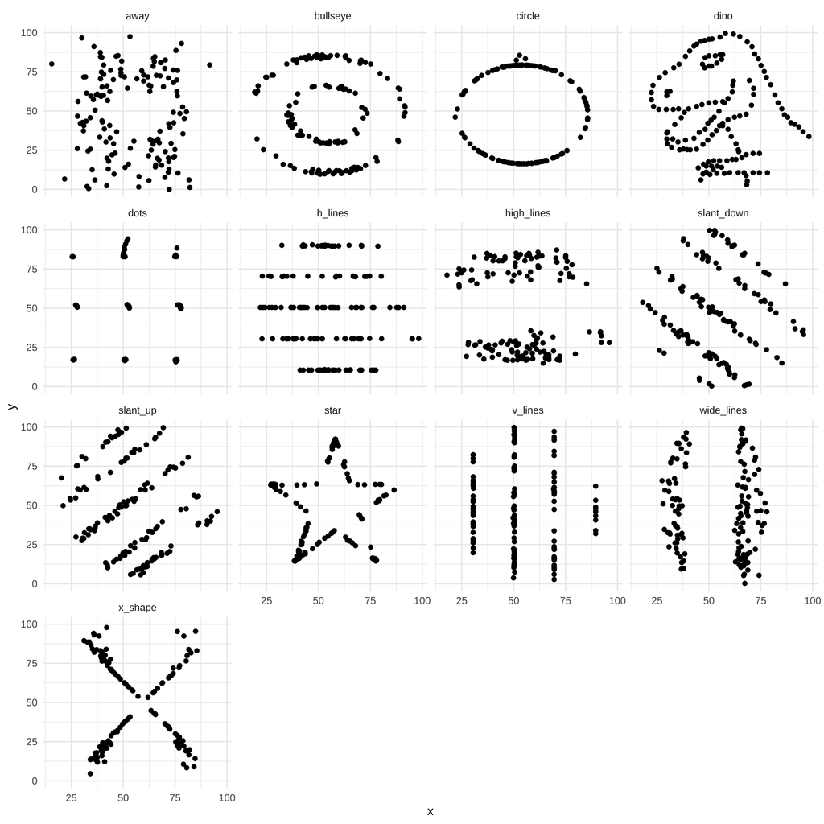

```r
ggplot(datasaurus_dozen, aes(x = x, y = y)) +
  geom_point() +
  facet_wrap(~dataset) +
  theme_minimal()
```

# Structure of a ggplot

Whereas the pipes (`%>%` and `|>`) are used to create tidy data wrangling and analysis workflows, ggplot functions are added together with `+`.

Function calls are applied in order as layers. Changing the order functions are called can therefore change the appearance of the plot.

```r
# get data
data_processed <- read_csv("../data/processed/data_processed.csv")

data_after_exclusions <- data_processed |>
  filter(exclude_amp == "include" &
           n_items == 3 &
           gender %in% c("male", "female"))
```

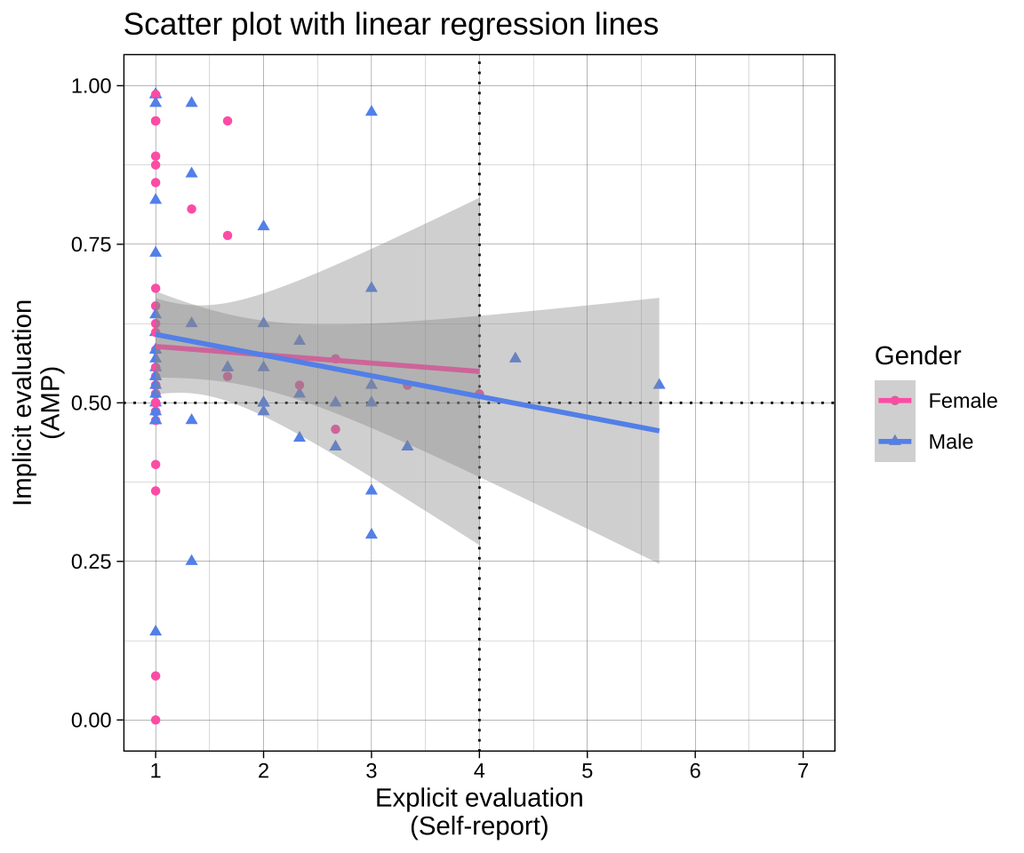

```r
# data and aesthetics calls
plot_1 <-
  ggplot(data = data_after_exclusions,
         aes(x = mean_self_report,
             y = amp_score,
             color = gender,
             shape = gender)) +
  # draw lines manually
  geom_vline(xintercept = 4, linetype = "dotted") +
  geom_hline(yintercept = 0.5, linetype = "dotted") +
  # draw geoms using the aesthetics (x, y, color and shape)
  ## points
  geom_point() +
  ## fit curves, in this case a linear model
  geom_smooth(method = "lm") +
  # adjust axis labels and ranges
  scale_x_continuous(name = "Explicit evaluation\n(Self-report)",
                     breaks = scales::breaks_pretty(n = 7)) +
  scale_y_continuous(name = "Implicit evaluation\n(AMP)") +
  # apply a theme
  theme_linedraw() +
  # adjust elements of the theme
  labs(title = "Scatter plot with linear regression lines",
       color = "Gender",
       shape = "Gender") +
  # adjust the colors
  scale_color_manual(values = c("female" = "#FF69B4",
                                "male" = "#6495ED"),
                     labels = c("female" = "Female",
                                "male" = "Male")) +
  # adjust the shapes
  scale_shape_manual(values = c("female" = 16,
                                "male" = 17),
                     labels = c("female" = "Female",
                                "male" = "Male")) +
  # display specific x and y coordinates without dropping data points (nb using `limits` drops data points, coord_cartesian does not)
  coord_cartesian(xlim = c(1, 7),
                  ylim = c(0, 1))

# display plot below chunk
plot_1
```

```r
# save plot to disk as png
ggsave(plot = plot_1,
       filename = "plots/plot_1.pdf",
       width = 6,
       height = 5)
```

Note that you can add additional function calls to objects later, e.g., overriding the previous theme_ call with a new one:

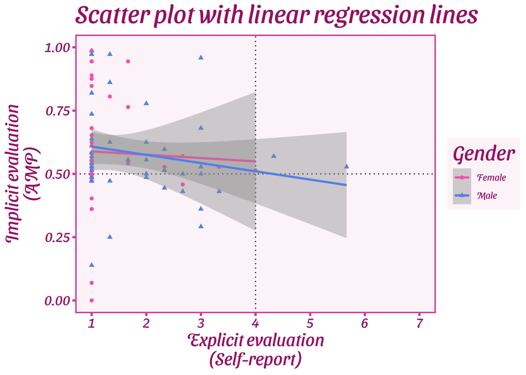

```r
plot_1 + theme_barbie()
```

# Histogram using `geom_histogram()`

## Simple plot for self-reports

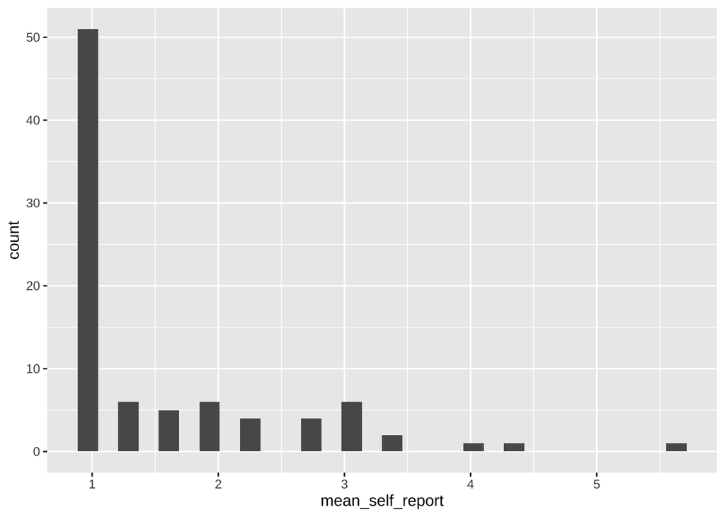

```r
ggplot(data = data_after_exclusions,
       aes(x = mean_self_report)) +
  geom_histogram()
```

## Slightly better plot for self-reports

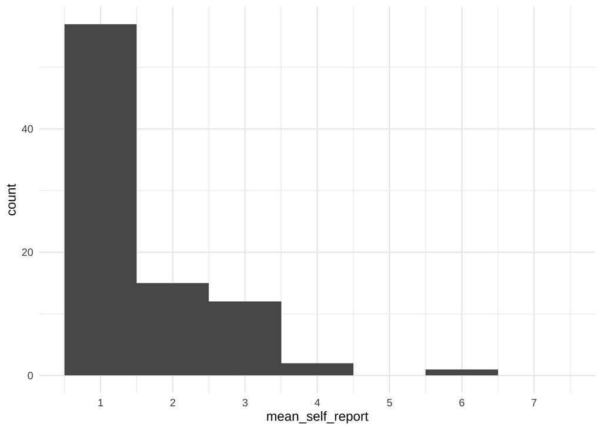

```r
ggplot(data = data_after_exclusions,
       aes(x = mean_self_report)) +
  # more intelligent choices for the binwidth and boundary
  geom_histogram(binwidth = 1, boundary = 0.5) +
  # labeling of the axis points
  scale_x_continuous(breaks = scales::breaks_pretty(n = 7),
                     limits = c(0.5, 7.5)) +
  theme_minimal()
```

## Exercise: Plot for gender

Create a similar plot for the gender variable in `data_processed` (ie before exclusions).

## Exercise: Plot for AMP

Create a similar plot for the AMP scores in `data_after_exclusions`.

- Exercise: How to add a dashed vertical line at the sample’s mean AMP score?

# Density plot using `geom_density()`

## Simple plot for self-reports

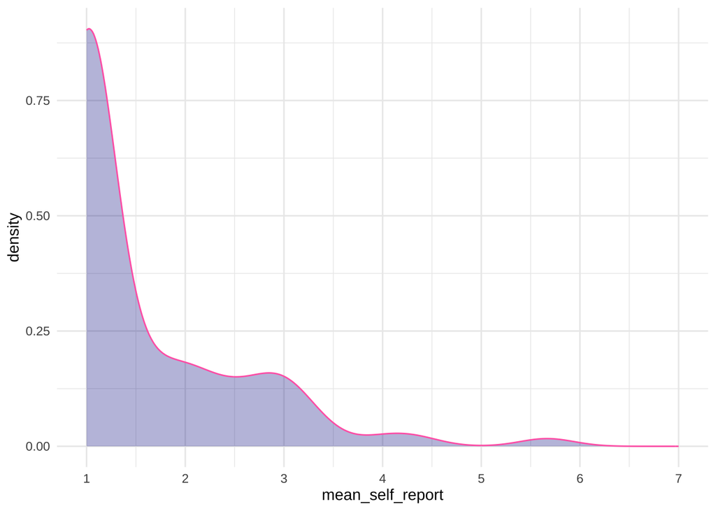

```r
ggplot(data = data_after_exclusions,
       aes(x = mean_self_report)) +
  # more intelligent choices for the binwidth and boundary
  geom_density(adjust = 1, # the degree of smoothing can be adjusted here
               color = "#FF69B4",
               fill = "darkblue",
               alpha = 0.3) +
  # labeling of the axis points
  scale_x_continuous(breaks = scales::breaks_pretty(n = 7),
                     limits = c(1, 7)) +
  theme_minimal()
```

## Exercise: Plot for AMP

Make a similar density plot for the AMP.

- Add a theme.
- Make the X axis breaks prettier.
- Name both axis names more clearly.

# Bar plot using `geom_col()`

Bar plots are bad and usually shouldn’t be used. But they are sometimes unavoidable, so here’s how to make them.

## Simple plot for AMP

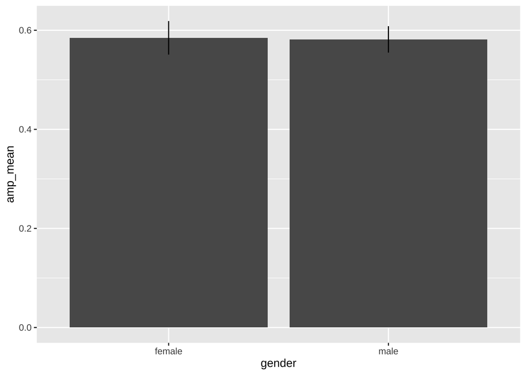

```r
# create the summary values to be plotted
summary_amp <- data_after_exclusions %>%
  group_by(gender) %>%
  summarize(amp_mean = mean(amp_score),
            amp_se = plotrix::std.error(amp_score))

# plot these values
ggplot(data = summary_amp,
       aes(x = gender,
           y = amp_mean)) +
  geom_col() +
  # geom_bar(stat = "identity") + # NB geom_col is equivalent to geom_bar when stat == "identity
  geom_linerange(aes(ymin = amp_mean - amp_se,
                     ymax = amp_mean + amp_se))
```

## Slightly better plot for AMP

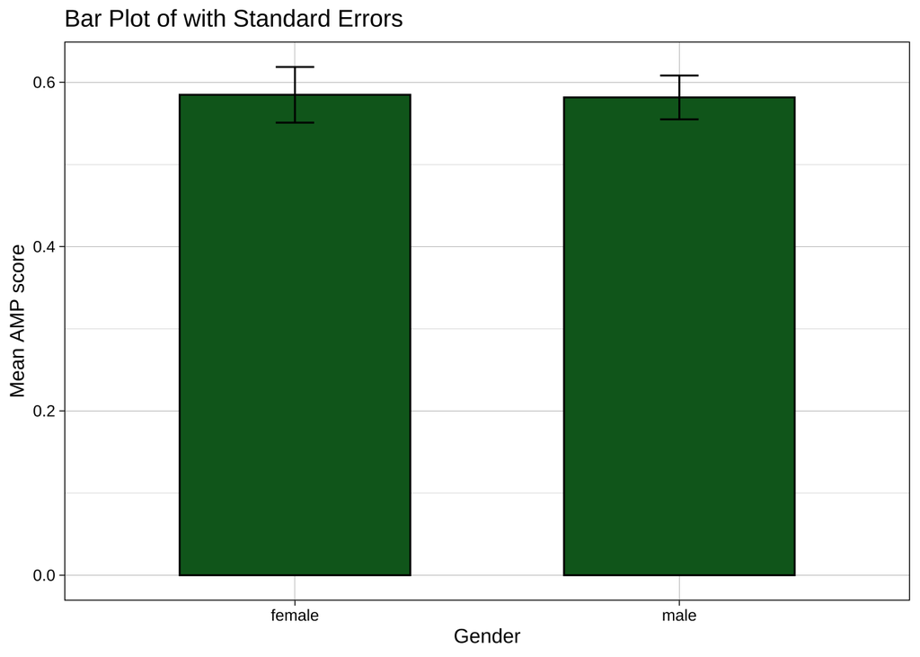

```r
ggplot(data = summary_amp,
       aes(x = gender,
           y = amp_mean)) +
  geom_col(fill = "#0b6623", # note that you can specify specific colors using hex codes or names
           color = "black",
           width = 0.6) +
  geom_errorbar(aes(ymin = amp_mean - amp_se,
                    ymax = amp_mean + amp_se),
                width = 0.1,
                color = "black") +
  labs(title = "Bar Plot of with Standard Errors",
       x = "Gender",
       y = "Mean AMP score") +
  theme_linedraw()
```

## Exercise: Plot for self-reports

Make a similar plot for the self-reports.

- Use `coord_flip()` to swap the X and Y axes.
- Exercise: How to capitalize ‘Male’ and ‘Female’ by wrangling the data before plotting?

# Combining plots

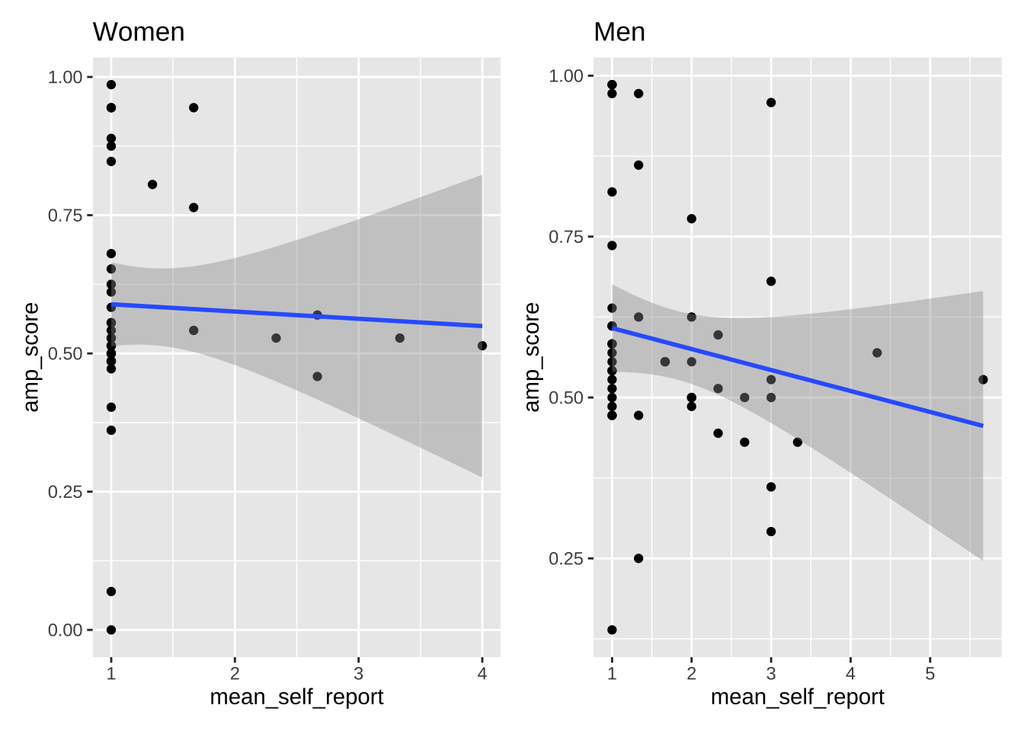

```r
plot_all <- data_after_exclusions |>
  ggplot(aes(x = mean_self_report,
             y = amp_score)) +
  geom_point() +
  geom_smooth(method = "lm") +
  ggtitle("All")

plot_women <- data_after_exclusions |>
  filter(gender == "female") |>
  ggplot(aes(x = mean_self_report,
             y = amp_score)) +
  geom_point() +
  geom_smooth(method = "lm") +
  ggtitle("Women")

plot_men <- data_after_exclusions |>
  filter(gender == "male") |>
  ggplot(aes(x = mean_self_report,
             y = amp_score)) +
  geom_point() +
  geom_smooth(method = "lm") +
  ggtitle("Men")

# combine these plots with different arrangements
plot_women + plot_men
```

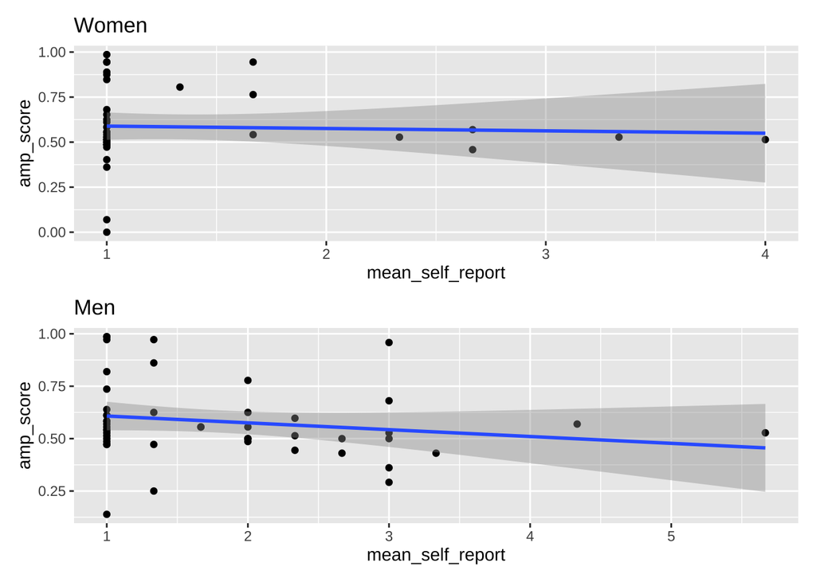

```r
plot_women + plot_men + plot_layout(ncol = 1)
```

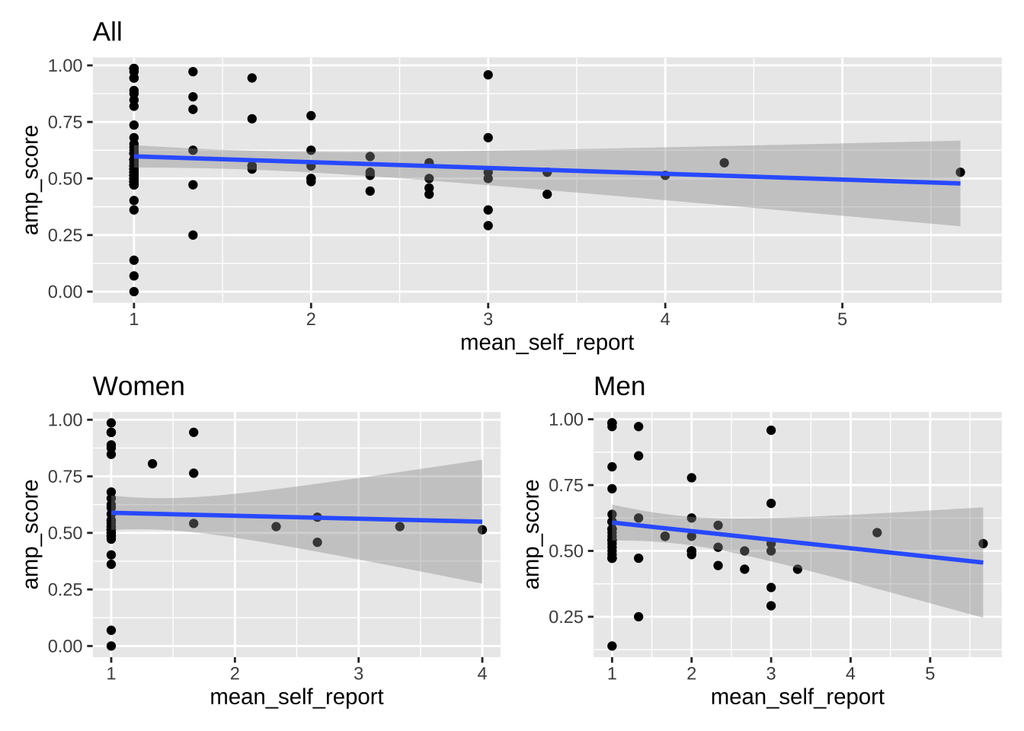

```r
plot_all / (plot_women + plot_men)
```

# Faceting plots

Without repeating yourself, you can also make a plot for different subsets using `facet_wrap()` or `facet_grid()`

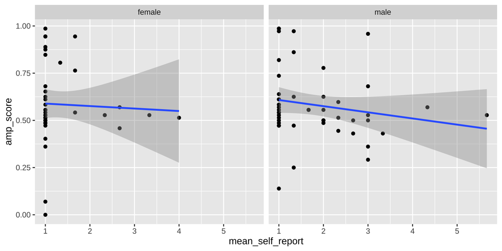

```r
ggplot(data = data_after_exclusions,
         aes(x = mean_self_report,
             y = amp_score)) +
  geom_point() +
  geom_smooth(method = "lm") +
  facet_wrap(~ gender)
```

## Exercise

Create a plot that assesses the association between self report scores and AMP scores. By wrangling `data_processed` more prior to plotting, and using `facet_grid()`, compare a) men vs women and b) participants who are 30+ years old vs younger than 30.

Improve the appearance of the plot, including its text, colors, theme, etc.